# Advanced input and output

GEOG 30323

March 21, 2023

## The ‘ins’ and ‘outs’ of data

- We’ve learned how to work with CSV files - which are probably the most common data format you’ll come across
- What if your data aren’t available in CSV format?
- Possible formats: Excel, database, fixed-width text, statistics packages, JSON, XML, …

### `pd.read_csv()`

- Also: `pd.read_table()`
- Designed for **delimited** text data
- Lots of options!

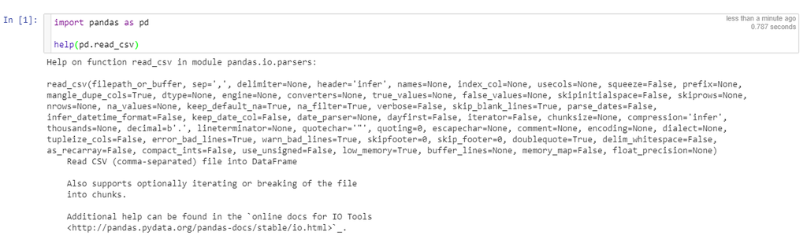

### Delimited text data

- Generally: each record on a different line of the text file; columns separated in some consistent way (hopefully)
- Common delimiters:
  - Comma `','`
  - Semi-colon `';'`
  - Pipe `'|'`
  - Tab (expressed as `'\t'` in `pandas`)
- Supplied to the `sep` parameter in `read_csv()`; defaults to comma

### Fixed-width text files

- Each column in the text file a specified (fixed) number of characters; generally, a data dictionary will specify the column widths
- Read into `pandas` with the `read_fwf()` function; supply a list of column widths to the `widths` parameter

### Excel files

- Accessible via the `read_excel()` function in `pandas`

### Data on the web

- Example: https://data.fortworthtexas.gov/

### Application programming interfaces (APIs)

- API (general definition): the way in which you can access a particular software application programmatically
  - For example: the `pandas` API comprises the functions, methods, etc. that you use in `pandas`
- Data API: interface that allows you to access **data** programmatically
  - Often: requests are made via URL; interact with data via URL parameters

### JavaScript Object Notation (JSON)

- Example: https://data.fortworthtexas.gov/resource/kr8h-9zxd.json

### JSON in `pandas`

- Convert JSON to data frames with the `read_json()` function
- Be careful with what you get back!

```python
import pandas as pd

api_call = 'https://data.fortworthtexas.gov/resource/kr8h-9zxd.json?streetname=BERRY'

berry = pd.read_json(api_call)

berry.head()
```

[output not shown]

### Why use APIs?

- Your programming knowledge can give you even more flexibility…

```python
def get_accidents(street_name):
    part1 = 'https://data.fortworthtexas.gov/resource/kr8h-9zxd.json?streetname='
    api_call = part1 + street_name
    return pd.read_json(api_call)

uni = get_accidents('UNIVERSITY')

uni.head()
```

[output not shown]

### Data on websites

[figure not shown]

### Web scraping

- Process of getting data **from** websites **into** your computing environment
- Python packages to accomplish this: `html5lib`, `BeautifulSoup`, `lxml`, `scrapy`
- Web scraping built into `pandas` with the `read_html()` function (for tables)
  - “Expect to do some cleanup after you call this function.”

### Web scraping in `pandas`

```python
url = 'https://www.espn.com/soccer/standings/_/league/ENG.1/season/2019'

epl = pd.read_html(url)

epl
```

[output not shown]

We get back a list of data frame objects with team names (with clean-up required) in the first data frame and team performance in the second

## Regular expressions

[figure not shown]

[Image source](https://www.commitstrip.com/en/2016/04/08/fing-patterns/)

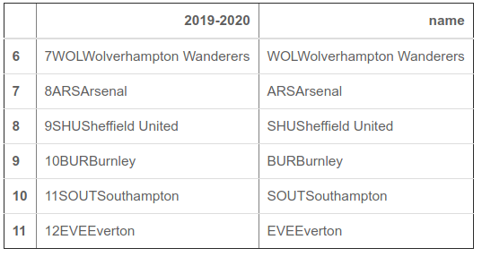

```python
teams = epl[0]

teams["name"] = teams["2019-2020"].str.replace("[0-9]", "")

teams[6:12]
```

- `np.where()`: If the specified condition is `True`, return the first supplied outcome; otherwise return the second supplied outcome

```python
import numpy as np

teams["firstfive"] = teams["name"].str[0:5]

teams["name"] = np.where(teams["firstfive"].str.isupper(),
                         teams["name"].str[4:],
                         teams["name"].str[3:])
```

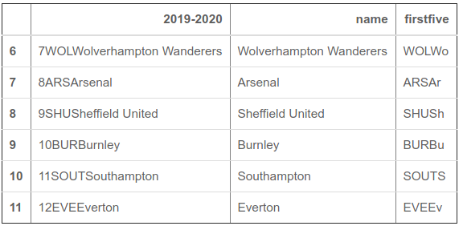

```python
teams[6:12]
```

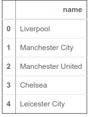

```python
teams.drop(["2019-2020", "firstfive"], axis = 1, inplace = True)

teams.head()
```

### Combining data frames by position

- The `concat()` function in **pandas**: stitches together data frames vertically (`axis = 0`) or horizontally (`axis = 1`); relies on row/column indices rather than key field value

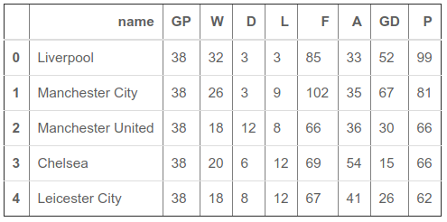

```python
epl_cleaned = pd.concat([teams, epl[1]], axis = 1)

epl_cleaned.head()
```

### Explore your data!

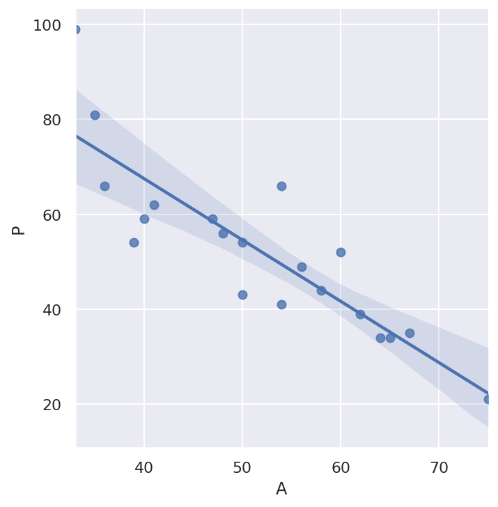

```python
import seaborn as sns
sns.set(style = "darkgrid")

sns.lmplot(data = epl_cleaned, x = "A", y = "P")
```

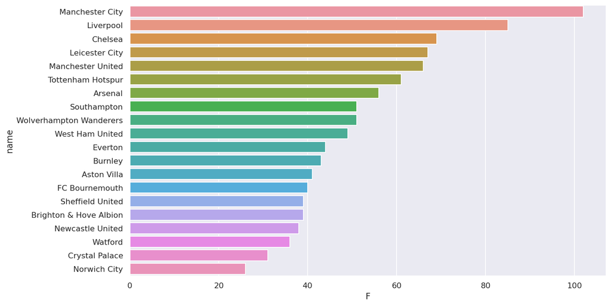

```python
sns.barplot(x = "F", y = "name",
            data = epl_cleaned.sort_values("F", ascending = False))
```

### Getting data out

- The `.to_xxx()` suite of methods allow you to write `pandas` data frames to a host of different formats

For example:

```python
epl_cleaned.to_csv('epl_standings.csv', index = False)
```